# 卷积神经网络

## 项目：为小狗识别应用编写算法

在此 notebook 中，我们已经为你提供一些模板代码，要成功完成此项目，你需要实现其他功能。除此之外，不需要修改所提供的代码。标题中以**（实现）**开头的部分表明你必须在下面的代码块中提供其他功能。我们会在每个部分提供说明，并在以“TODO”开头的代码块中提供实现细节。请仔细阅读说明。

> **注意**：完成所有代码实现后，最后需要将 iPython Notebook 导出为 HTML 文档。在将 notebook 导出为 HTML 前，请运行所有代码单元格，使审阅者能够查看最终实现和输出结果。然后导出 notebook，方法是：使用顶部的菜单并依次转到**文件 -> 下载为 -> HTML (.html)**。提交内容应该同时包含此 notebook 和完成的文档。

除了实现代码之外，还需要回答与项目和代码实现相关的问题。请仔细阅读每个问题，并在**答案：**下方的文本框中填写答案。我们将根据每个问题的答案以及实现代码评估你提交的项目。

> **注意：**可以通过 **Shift + Enter** 键盘快捷键执行代码和标记单元格，并且可以通过双击单元格进入编辑模式，编辑标记单元格。

审阅标准还包含可选的“锦上添花”建议，可以指导你在满足最低要求的基础上改进项目。如果你打算采纳这些建议，则应该在此 Jupyter notebook 中添加代码。

### 为何要完成这道练习

在此 notebook 中，你将开发一种可用于移动应用或网络应用的算法。最终你的代码将能够将任何用户提供的图像作为输入。如果从图像中检测出小狗，该算法将大致识别出小狗品种。如果检测出人脸，该算法将大致识别出最相似的小狗品种。下图显示了最终项目的潜在示例输出（但是我们希望每个学员的算法行为都不一样。）。

[figure not shown]

在此实际应用中，你需要将一系列模型整合到一起并执行不同的任务；例如，检测图中人脸的算法与推理小狗品种的 CNN 将不一样。有很多地方都可能会出错，没有什么完美的算法。即使你的答案不完美，也可以创造有趣的用户体验。

### 项目规划

我们将此 notebook 分成了几个独立的步骤。你可以通过以下链接浏览此 notebook。

- 第 0 步：导入数据集
- 第 1 步：检测人脸
- 第 2 步：检测小狗
- 第 3 步：（从头开始）创建分类小狗品种的 CNN
- 第 4 步：（使用迁移学习）创建分类小狗品种的 CNN
- 第 5 步：编写算法
- 第 6 步：测试算法

## 第 0 步：导入数据集

首先下载人脸和小狗数据集：

- 下载[小狗数据集](https://s3-us-west-1.amazonaws.com/udacity-aind/dog-project/dogImages.zip)。解压文件并将其放入此项目的主目录中，位置为 `/dog_images`。
- 下载[人脸数据集](https://s3-us-west-1.amazonaws.com/udacity-aind/dog-project/lfw.zip)。解压文件并将其放入此项目的主目录中，位置为 `/lfw`。

*注意如果你使用的是 Windows 设备，建议使用 [7zip](http://www.7-zip.org/) 解压文件。*

在下面的代码单元格中将人脸 (LFW) 数据集和小狗数据集的文件路径保存到 NumPy 数组 `human_files` 和 `dog_files` 中。

```python
import numpy as np
from glob import glob

# load filenames for human and dog images
human_files = np.array(glob("data/lfw/*/*"))
dog_files = np.array(glob("data/dogimages/*/*/*"))


# print number of images in each dataset
print('There are %d total human images.' % len(human_files))
print('There are %d total dog images.' % len(dog_files))
```

```
There are 13234 total human images.
There are 8351 total dog images.
```

## 第 1 步：检测人脸

在此部分，我们使用 OpenCV 的[哈儿特征级联分类器](http://docs.opencv.org/trunk/d7/d8b/tutorial_py_face_detection.html)检测图像中的人脸。

OpenCV 提供了很多预训练的人脸检测器，它们以 XML 文件的形式存储在 [github](https://github.com/opencv/opencv/tree/master/data/haarcascades) 上。我们下载了其中一个检测器并存储在 `haarcascades` 目录中。在下个代码单元格中，我们将演示如何使用此检测器从样本图像中检测人脸。

```
Number of faces detected: 1
```

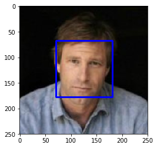

```python
import cv2
import matplotlib.pyplot as plt
%matplotlib inline

# extract pre-trained face detector
face_cascade = cv2.CascadeClassifier('haarcascades/haarcascade_frontalface_alt.xml')

# load color (BGR) image
img = cv2.imread(human_files[0])
# convert BGR image to grayscale
gray = cv2.cvtColor(img, cv2.COLOR_BGR2GRAY)

# find faces in image
faces = face_cascade.detectMultiScale(gray)

# print number of faces detected in the image
print('Number of faces detected:', len(faces))

# get bounding box for each detected face
for (x,y,w,h) in faces:
    # add bounding box to color image
    cv2.rectangle(img,(x,y),(x+w,y+h),(255,0,0),2)

# convert BGR image to RGB for plotting
cv_rgb = cv2.cvtColor(img, cv2.COLOR_BGR2RGB)

# display the image, along with bounding box
plt.imshow(cv_rgb)
plt.show()
```

在使用任何人脸检测器之前，标准做法是将图像转换为灰阶图像。`detectMultiScale` 函数会执行存储在 `face_cascade` 中的分类器并将灰阶图像当做参数。

在上述代码中，`faces` 是一个包含检测到的人脸的 numpy 数组，其中每行对应一张检测到的人脸。检测到的每张人脸都是一个一维数组，其中有四个条目，分别指定了检测到的人脸的边界框。数组中的前两个条目（在上述代码中提取为 `x` 和`y`）指定了左上角边界框的水平和垂直位置。数组中的后两个条目（提取为 `w` 和 `h`）指定了边界框的宽和高。

### 编写人脸检测器

我们可以编写一个函数，如果在图像中检测到人脸，该函数将返回 `True`，否则返回 `False`。此函数称为 `face_detector`，参数为图像的字符串文件路径，并出现在以下代码块中。

```python
# returns "True" if face is detected in image stored at img_path
def face_detector(img_path):
    img = cv2.imread(img_path)
    gray = cv2.cvtColor(img, cv2.COLOR_BGR2GRAY)
    faces = face_cascade.detectMultiScale(gray)
    return len(faces) > 0
```

### （实现）评估人脸检测器

**问题 1：**使用以下代码单元格测试 `face_detector` 函数的性能。

- 对于 `human_files` 中的前100 张图像，有多少图像检测到了人脸？
- 对于 `dog_files` 中的前100 张图像，有多少图像检测到了人脸？

理想情况下，我们希望所有人脸图像都能检测到人脸，所有小狗图像都不能检测到人脸。我们的算法不能满足此目标，但是依然达到了可接受的水平。我们针对每个数据集的前 100 张图像提取出文件路径，并将它们存储在 numpy 数组 `human_files_short` 和 `dog_files_short` 中。

**答案：** （请在此单元格中填写结果和/或百分比）

`human_files` 中的前100 张图像，96张图像检测到了人脸

`dog_files` 中的前100 张图像，18张图像检测到了人脸

```python
from tqdm import tqdm

human_files_short = human_files[:100]
dog_files_short = dog_files[:100]



#-#-# Do NOT modify the code above this line. #-#-#

## TODO: Test the performance of the face_detector algorithm
## on the images in human_files_short and dog_files_short.

count_human = 0
count_dog = 0


for i in range(100):
    if(face_detector(human_files_short[i])==True):
        count_human +=1


    if(face_detector(dog_files_short[i])==True):
        count_dog +=1
```

```python
print("count_human:",count_human)
print("count_dog:",count_dog)
```

```
count_human: 96
count_dog: 18
```

建议在算法中使用 OpenCV 的人脸检测器来检测人脸图像，但是你也可以尝试其他方法，尤其是利用深度学习的方法:)。请在以下代码单元格中设计并测试你的人脸检测算法。如果你打算完成此_可选_任务，请报告 `human_files_short` 和 `dog_files_short` 的效果。

```python
### (Optional)
### TODO: Test performance of anotherface detection algorithm.
### Feel free to use as many code cells as needed.
```

## 第 2 步：检测小狗

在此部分，我们使用[预训练的模型](http://pytorch.org/docs/master/torchvision/models.html)检测图像中的小狗。

### 获取预训练的 VGG-16 模型

以下代码单元格会下载 VGG-16 模型以及在 [ImageNet](http://www.image-net.org/) 上训练过的权重，ImageNet 是一个非常热门的数据集，可以用于图像分类和其他视觉任务。ImageNet 包含 1000 万以上的 URL，每个都链接到包含某个对象的图像，这些对象分成了 [1000 个类别](https://gist.github.com/yrevar/942d3a0ac09ec9e5eb3a)。

```python
import torch
import torchvision.models as models

# define VGG16 model
VGG16 = models.vgg16(pretrained=True)

# check if CUDA is available
use_cuda = torch.cuda.is_available()

# move model to GPU if CUDA is available
if use_cuda:
    VGG16 = VGG16.cuda()
```

```python
print(use_cuda)
```

```
True
```

如果给定一张图像，此预训练的 VGG-16 模型能够针对图像中的对象返回预测结果（属于 ImageNet 中的 1000 个潜在类别之一）。

### （实现）使用预训练的模型做出预测

在下个代码单元格中，你将编写一个函数，它将图像路径（例如 `'dogImages/train/001.Affenpinscher/Affenpinscher_00001.jpg'`）当做输入，并返回预训练 VGG-16 模型预测的 ImageNet 类别对应的索引。输出应该始终是在 0 - 999（含）之间的整数。

在编写该函数之前，请阅读此 [PyTorch 文档](http://pytorch.org/docs/stable/torchvision/models.html)，了解如何针对预训练的模型预处理张量。

```python
from PIL import Image
import torchvision.transforms as transforms
import torchvision.datasets as datasets
```

```python
def load_image(img_path):
    image = Image.open(img_path).convert('RGB')
    # resize to (244, 244) because VGG16 accept this shape
    in_transform = transforms.Compose([
                        transforms.Resize(size=(244, 244)),
                        transforms.ToTensor()]) # normalizaiton parameters from pytorch doc.

    # discard the transparent, alpha channel (that's the :3) and add the batch dimension
    image = in_transform(image)[:3,:,:].unsqueeze(0)
    return image
```

```python
def VGG16_predict(img_path):
    '''
    Use pre-trained VGG-16 model to obtain index corresponding to
    predicted ImageNet class for image at specified path

    Args:
        img_path: path to an image

    Returns:
        Index corresponding to VGG-16 model's prediction
    '''


    ## TODO: Complete the function.
    ## Load and pre-process an image from the given img_path
    ## Return the *index* of the predicted class for that image
     #读取图片
    img = load_image(img_path)
    if use_cuda:
        img = img.cuda()
    ret = VGG16(img)

    return torch.max(ret,1)[1].item()  # predicted class index
```

```python
a = VGG16_predict('data/dogImages/train/001.Affenpinscher/Affenpinscher_00001.jpg')
```

```python
print(a)
```

```
252
```

### （实现）编写小狗检测器

查看该[字典](https://gist.github.com/yrevar/942d3a0ac09ec9e5eb3a)后，你将发现：小狗对应的类别按顺序排列，对应的键是 151-268（含），包含从 `'Chihuahua'` 到 `'Mexican hairless'` 的所有类别。因此，要检查预训练的 VGG-16 模型是否预测某个图像包含小狗，我们只需检查预训练模型预测的索引是否在 151 - 268（含）之间。

请根据这些信息完成下面的 `dog_detector` 函数，如果从图像中检测出小狗，它将返回 `True`（否则返回 `False`）。

```python
### returns "True" if a dog is detected in the image stored at img_path
from PIL import Image
import torchvision.transforms as transforms
import torchvision.datasets as datasets
import numpy as np
def dog_detector(img_path):
    ## TODO: Complete the function.
    transform =  transforms.Compose([
                        transforms.Resize(size=(244, 244)),
                        transforms.ToTensor()])
    img = Image.open(img_path)

    index = VGG16_predict(img_path)
    return index >= 151 and index <= 268 # true/false
```

```python
b = dog_detector('data/dogImages/train/001.Affenpinscher/Affenpinscher_00001.jpg')
```

```python
print(b)
```

```
True
```

### （实现）评估小狗检测器

**问题 2：**在以下代码单元格中测试 `dog_detector` 的效果。

- 对于 `human_files_short` 中的图像，有多少图像检测到了小狗？
- 对于 `dog_files_short` 中的图像，有多少图像检测到了小狗？

**答案：**

```python
### TODO: Test the performance of the dog_detector function
### on the images in human_files_short and dog_files_short.
count_check_human =0
count_check_dog =0


for i in range(100):
    if(dog_detector(human_files_short[i])==True):
        count_human +=1


    if(dog_detector(dog_files_short[i])==True):
        count_check_dog +=1
```

```python
print("count_check_human:",count_check_human)
print("count_check_dog:",count_check_dog)
```

```
count_check_human: 0
count_check_dog: 95
```

建议在算法中使用 VGG-16 检测小狗图像，但是你也可以尝试其他预训练的网络（例如 [Inception-v3](http://pytorch.org/docs/master/torchvision/models.html#inception-v3)、[ResNet-50](http://pytorch.org/docs/master/torchvision/models.html#id3) 等）。请在以下代码单元格中测试其他预训练的 PyTorch 模型。如果你打算完成此_可选_任务，请报告 `human_files_short` 和 `dog_files_short` 的效果。

```python
### (Optional)
### TODO: Report the performance of another pre-trained network.
### Feel free to use as many code cells as needed.
```

## 第 3 步：（从头开始）创建分类小狗品种的 CNN

创建好从图像中检测人脸和小狗的函数后，我们需要预测图像中的小狗品种。在这一步，你需要创建一个分类小狗品种的 CNN。你必须从头创建一个 CNN（因此暂时不能使用迁移学习。），并且测试准确率必须至少达到 10%。在此 notebook 的第 4 步，你将使用迁移学习创建 CNN，并且能够获得很高的准确率。

预测图中小狗的品种是一项非常难的挑战。说实话，即使是我们人类，也很难区分布列塔尼猎犬和威尔斯激飞猎犬。

| 布列塔尼猎犬 | 威尔斯激飞猎犬 |
| --- | --- |

还有很多其他相似的狗品种（例如卷毛寻回犬和美国水猎犬）。

| 卷毛寻回犬 | 美国水猎犬 |
| --- | --- |

同理，拉布拉多有黄色、巧克力色和黑色品种。基于视觉的算法需要克服这种同一类别差异很大的问题，并决定如何将所有这些不同肤色的小狗分类为相同的品种。

| 黄色拉布拉多 | 巧克力色拉布拉多 | 黑色拉布拉多 |
| --- | --- | --- |

随机猜测的效果很差：除了类别数量不太平衡之外，随机猜测的正确概率约为 1/133，准确率不到 1%。

在深度学习领域，实践比理论知识靠谱得到。请尝试多种不同的架构，并相信你的直觉。希望你可以从学习中获得乐趣！

### （实现）为小狗数据集指定数据加载器

在以下代码单元格中编写三个独立的[数据加载器](http://pytorch.org/docs/stable/data.html#torch.utils.data.DataLoader)，用于训练、验证和测试小狗图像数据集（分别位于 `dog_images/train`、`dog_images/valid` 和 `dog_images/test` 下）。[此自定义数据集文档](http://pytorch.org/docs/stable/torchvision/datasets.html)或许对你有帮助。如果你想增强训练和/或验证数据，请参阅各种[转换方法](http://pytorch.org/docs/stable/torchvision/transforms.html?highlight=transform)！

```python
import os
from torchvision import datasets
import torchvision.transforms as transforms
import torch
import numpy as np
from PIL import ImageFile
import cv2
import matplotlib.pyplot as plt
ImageFile.LOAD_TRUNCATED_IMAGES = True
```

```python
### TODO: Write data loaders for training, validation, and test sets
## Specify appropriate transforms, and batch_sizes

batch_size = 20
num_workers = 0


data_dir = 'data/dogImages'
train_dir = os.path.join(data_dir, 'train/')
test_dir = os.path.join(data_dir, 'test/')
valid_dir = os.path.join(data_dir, 'valid/')
```

```python
# standard_normalization = transforms.Normalize(mean=[0.5, 0.5, 0.5],
#                                               std=[0.5, 0.5, 0.5])

standard_normalization = transforms.Normalize(mean=[0.485, 0.456, 0.406],
                                              std=[0.229, 0.224, 0.225])
```

```python
data_transforms = {'train': transforms.Compose([transforms.RandomResizedCrop(224),
                                     transforms.RandomHorizontalFlip(),
                                     transforms.ToTensor(),
                                     standard_normalization]),
                   'val': transforms.Compose([transforms.Resize(size=(224,224)),
                                     transforms.ToTensor(),
                                     standard_normalization]),
                   'test': transforms.Compose([transforms.Resize(size=(224,224)),
                                     transforms.ToTensor(),
                                     standard_normalization])
                  }
```

```python
train_data = datasets.ImageFolder(train_dir, transform=data_transforms['train'])
valid_data = datasets.ImageFolder(valid_dir, transform=data_transforms['val'])
test_data = datasets.ImageFolder(test_dir, transform=data_transforms['test'])
```

```python
print('Num training images: ', len(train_data))
print('Num test images: ', len(test_data))
print('Num valid images: ', len(valid_data))
```

```
Num training images:  6680
Num test images:  836
Num valid images:  835
```

```python
# define dataloader parameters

# prepare data loaders
train_loader = torch.utils.data.DataLoader(train_data, batch_size=batch_size,shuffle=True,
                                           num_workers=num_workers)
test_loader = torch.utils.data.DataLoader(test_data, batch_size=batch_size,shuffle=True,
                                          num_workers=num_workers)
valid_loader = torch.utils.data.DataLoader(valid_data, batch_size=batch_size,shuffle=True,
                                          num_workers=num_workers)


loaders = {'test':test_loader,'valid':valid_loader,'train': train_loader }
```

[output not shown]

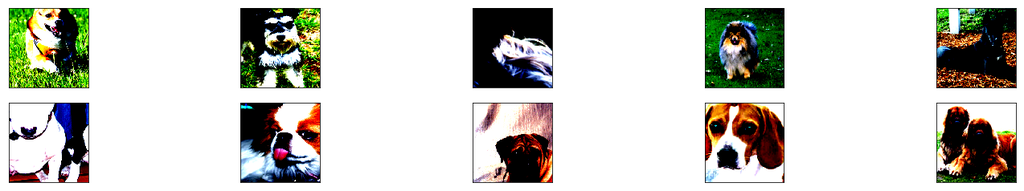

```python
# Visualize some sample data

# obtain one batch of training images
dataiter = iter(loaders['train'])
images, labels = dataiter.next()
images = images.numpy() # convert images to numpy for display

# plot the images in the batch, along with the corresponding labels
fig = plt.figure(figsize=(25, 4))
for idx in np.arange(10):
    ax = fig.add_subplot(2, 10/2, idx+1, xticks=[], yticks=[])
    plt.imshow(np.transpose(images[idx], (1, 2, 0)))
```

**问题 3：**描述你所选的数据预处理流程。

- 你是如何调整图像大小的（裁剪、拉伸等）？你选择的输入张量大小是多少，为何？
- 你是否决定增强数据集？如果是，如何增强（平移、翻转、旋转等）？如果否，理由是？

**答案**：

创建分类小狗品种的 CNN。使用以下代码单元格中的模板。

```python
from PIL import ImageFile
ImageFile.LOAD_TRUNCATED_IMAGES = True

num_classes = 133 # total classes of dog breeds
```

```python
import torch.nn as nn
import torch.nn.functional as F
import numpy as np

# define the CNN architecture
class Net(nn.Module):
    ### TODO: choose an architecture, and complete the class
    def __init__(self):
        super(Net, self).__init__()
        ## Define layers of a CNN
        self.conv1 = nn.Conv2d(3, 32, 3,stride=2, padding=1)
        self.conv2 = nn.Conv2d(32, 64, 3, stride=2,  padding=1)
        self.conv3 = nn.Conv2d(64, 128, 3, padding=1)


        # pool
        self.pool = nn.MaxPool2d(2, 2)

        # fully-connected
        self.fc1 = nn.Linear(7*7*128, 500)
        self.fc2 = nn.Linear(500, num_classes)

        # drop-out
        self.dropout = nn.Dropout(0.25)

    def forward(self, x):
        ## Define forward behavior
        x = F.relu(self.conv1(x))
        x = self.pool(x)
        x = F.relu(self.conv2(x))
        x = self.pool(x)
        x = F.relu(self.conv3(x))
        x = self.pool(x)


        # flatten
        x = x.view(-1, 7*7*128)

        x = self.dropout(x)
        x = F.relu(self.fc1(x))

        x = self.dropout(x)
        x = self.fc2(x)
        return x

#-#-# You so NOT have to modify the code below this line. #-#-#

# instantiate the CNN
model_scratch = Net()
print(model_scratch)

# move tensors to GPU if CUDA is available
if use_cuda:
    model_scratch.cuda()
```

```
Net(
  (conv1): Conv2d(3, 32, kernel_size=(3, 3), stride=(2, 2), padding=(1, 1))
  (conv2): Conv2d(32, 64, kernel_size=(3, 3), stride=(2, 2), padding=(1, 1))
  (conv3): Conv2d(64, 128, kernel_size=(3, 3), stride=(1, 1), padding=(1, 1))
  (pool): MaxPool2d(kernel_size=2, stride=2, padding=0, dilation=1, ceil_mode=False)
  (fc1): Linear(in_features=6272, out_features=500, bias=True)
  (fc2): Linear(in_features=500, out_features=133, bias=True)
  (dropout): Dropout(p=0.25)
)
```

**问题 4：**列出获得最终 CNN 结构的步骤以及每步的推理过程。

### （实现）指定损失函数和优化器

在下个代码单元格中指定[损失函数](http://pytorch.org/docs/stable/nn.html#loss-functions)和[优化器](http://pytorch.org/docs/stable/optim.html)。在下面将所选的损失函数另存为 `criterion_scratch`，并将优化器另存为 `optimizer_scratch`。

```python
import torch.optim as optim

### TODO: select loss function
criterion_scratch  = nn.CrossEntropyLoss()

### TODO: select optimizer
optimizer_scratch  =  optim.SGD(model_scratch.parameters(), lr=0.05)
```

### （实现）训练和验证模型

在以下代码单元格中训练和验证模型。[将最终模型参数](http://pytorch.org/docs/master/notes/serialization.html)保存到以下文件路径：`'model_scratch.pt'`。

```python
def train(n_epochs, loaders, model, optimizer, criterion, use_cuda, save_path, last_validation_loss=None):
    """returns trained model"""
    # initialize tracker for minimum validation loss
    if last_validation_loss is not None:
        valid_loss_min = last_validation_loss
    else:
        valid_loss_min = np.Inf

    for epoch in range(1, n_epochs+1):
        # initialize variables to monitor training and validation loss
        train_loss = 0.0
        valid_loss = 0.0

        ###################
        # train the model #
        ###################
        model.train()
        for batch_idx, (data, target) in enumerate(loaders['train']):
            # move to GPU
            if use_cuda:
                data, target = data.cuda(), target.cuda()
            ## find the loss and update the model parameters accordingly
            ## record the average training loss, using something like
            ## train_loss = train_loss + ((1 / (batch_idx + 1)) * (loss.data - train_loss))

            # initialize weights to zero
            optimizer.zero_grad()

            output = model(data)

            # calculate loss
            loss = criterion(output, target)

            # back prop
            loss.backward()

            # grad
            optimizer.step()

            train_loss = train_loss + ((1 / (batch_idx + 1)) * (loss.data - train_loss))

            if batch_idx % 100 == 0:
                print('Epoch %d, Batch %d loss: %.6f' %
                  (epoch, batch_idx + 1, train_loss))

        ######################
        # validate the model #
        ######################
        model.eval()
        for batch_idx, (data, target) in enumerate(loaders['valid']):
            # move to GPU
            if use_cuda:
                data, target = data.cuda(), target.cuda()
            ## update the average validation loss
            output = model(data)
            loss = criterion(output, target)
            valid_loss = valid_loss + ((1 / (batch_idx + 1)) * (loss.data - valid_loss))


        # print training/validation statistics
        print('Epoch: {} \tTraining Loss: {:.6f} \tValidation Loss: {:.6f}'.format(
            epoch,
            train_loss,
            valid_loss
            ))

        ## TODO: save the model if validation loss has decreased
        if valid_loss < valid_loss_min:
            torch.save(model.state_dict(), save_path)
            print('Validation loss decreased ({:.6f} --> {:.6f}).  Saving model ...'.format(
            valid_loss_min,
            valid_loss))
            valid_loss_min = valid_loss

    # return trained model
    return model
```

```python
# train the model
model_scratch = train(15, loaders, model_scratch, optimizer_scratch,
                      criterion_scratch, use_cuda, 'model_scratch.pt')
```

```
Epoch 1, Batch 1 loss: 4.871272
Epoch 1, Batch 101 loss: 4.885429
Epoch 1, Batch 201 loss: 4.878995
Epoch 1, Batch 301 loss: 4.864961
Epoch: 1 	Training Loss: 4.861953 	Validation Loss: 4.827124
Validation loss decreased (inf --> 4.827124).  Saving model ...
Epoch 2, Batch 1 loss: 4.930179
Epoch 2, Batch 101 loss: 4.804274
Epoch 2, Batch 201 loss: 4.791356
Epoch 2, Batch 301 loss: 4.778418
Epoch: 2 	Training Loss: 4.771212 	Validation Loss: 4.669437
Validation loss decreased (4.827124 --> 4.669437).  Saving model ...
Epoch 3, Batch 1 loss: 4.651063
Epoch 3, Batch 101 loss: 4.652472
Epoch 3, Batch 201 loss: 4.643903
Epoch 3, Batch 301 loss: 4.631507
Epoch: 3 	Training Loss: 4.633007 	Validation Loss: 4.517988
Validation loss decreased (4.669437 --> 4.517988).  Saving model ...
Epoch 4, Batch 1 loss: 4.433335
Epoch 4, Batch 101 loss: 4.553155
Epoch 4, Batch 201 loss: 4.553214
Epoch 4, Batch 301 loss: 4.556932
Epoch: 4 	Training Loss: 4.557496 	Validation Loss: 4.401508
Validation loss decreased (4.517988 --> 4.401508).  Saving model ...
Epoch 5, Batch 1 loss: 4.634662
Epoch 5, Batch 101 loss: 4.522198
Epoch 5, Batch 201 loss: 4.518325
Epoch 5, Batch 301 loss: 4.506662
Epoch: 5 	Training Loss: 4.501890 	Validation Loss: 4.416162
Epoch 6, Batch 1 loss: 4.489560
Epoch 6, Batch 101 loss: 4.449125
Epoch 6, Batch 201 loss: 4.454746
Epoch 6, Batch 301 loss: 4.439883
Epoch: 6 	Training Loss: 4.436327 	Validation Loss: 4.300265
Validation loss decreased (4.401508 --> 4.300265).  Saving model ...
Epoch 7, Batch 1 loss: 4.227088
Epoch 7, Batch 101 loss: 4.356337
Epoch 7, Batch 201 loss: 4.380315
Epoch 7, Batch 301 loss: 4.379504
Epoch: 7 	Training Loss: 4.372360 	Validation Loss: 4.240331
```

[output cut: 32 more lines]

```
Epoch 13, Batch 201 loss: 4.019108
Epoch 13, Batch 301 loss: 4.020298
Epoch: 13 	Training Loss: 4.017864 	Validation Loss: 4.039201
Epoch 14, Batch 1 loss: 3.886884
Epoch 14, Batch 101 loss: 3.928526
Epoch 14, Batch 201 loss: 3.950157
Epoch 14, Batch 301 loss: 3.956234
Epoch: 14 	Training Loss: 3.954800 	Validation Loss: 4.013237
Validation loss decreased (4.038683 --> 4.013237).  Saving model ...
Epoch 15, Batch 1 loss: 4.269781
Epoch 15, Batch 101 loss: 3.870636
Epoch 15, Batch 201 loss: 3.890878
Epoch 15, Batch 301 loss: 3.905852
Epoch: 15 	Training Loss: 3.904059 	Validation Loss: 3.862114
Validation loss decreased (4.013237 --> 3.862114).  Saving model ...
```

```python
# load the model that got the best validation accuracy
model_scratch.load_state_dict(torch.load('model_scratch.pt'))
```

### （实现）测试模型

在小狗图像测试数据集上尝试模型。在以下代码单元格中计算并输出测试损失和准确率。确保测试准确率高于 10%。

```python
def test(loaders, model, criterion, use_cuda):

    # monitor test loss and accuracy
    test_loss = 0.
    correct = 0.
    total = 0.

    for batch_idx, (data, target) in enumerate(loaders['test']):
        # move to GPU
        if use_cuda:
            data, target = data.cuda(), target.cuda()
        # forward pass: compute predicted outputs by passing inputs to the model
        output = model(data)
        # calculate the loss
        loss = criterion(output, target)
        # update average test loss
        test_loss = test_loss + ((1 / (batch_idx + 1)) * (loss.data - test_loss))
        # convert output probabilities to predicted class
        pred = output.data.max(1, keepdim=True)[1]
        # compare predictions to true label
        correct += np.sum(np.squeeze(pred.eq(target.data.view_as(pred))).cpu().numpy())
        total += data.size(0)

    print('Test Loss: {:.6f}\n'.format(test_loss))

    print('\nTest Accuracy: %2d%% (%2d/%2d)' % (
        100. * correct / total, correct, total))
```

```python
#  call test function
test(loaders, model_scratch, criterion_scratch, use_cuda)
```

```
Test Loss: 3.851602


Test Accuracy: 11% (97/836)
```

## 第 4 步：（使用迁移学习）创建分类小狗品种的 CNN

现在你将使用迁移学习创建能够识别图中小狗品种的 CNN。你的 CNN 必须在测试集上至少达到 60% 的准确率。

### （实现）为小狗数据集指定数据加载器

在以下代码单元格中编写三个独立的[数据加载器](http://pytorch.org/docs/master/data.html#torch.utils.data.DataLoader)，用于训练、验证和测试小狗图像数据集（分别位于 `dogImages/train`、`dogImages/valid` 和 `dogImages/test` 下）。

**你也可以使用在从头开始创建 CNN 这一步时创建的同一数据加载器**。

```python
## TODO: Specify data loaders
#使用之前的数据加载器
```

### （实现）模型架构

使用迁移学习创建分类小狗品种的 CNN。在以下代码单元格中填写代码并将初始化的模型另存为变量 `model_transfer`。

```python
import torchvision.models as models
import torch.nn as nn
import torch.optim as optim


## TODO: Specify model architecture
model_transfer = models.vgg16(pretrained=True)

num_classes = 133

use_cuda = torch.cuda.is_available()
```

```python
## TODO: add a last linear layer  that maps n_inputs -> 5 flower classes
## new layers automatically have requires_grad = True
import torch.nn as nn

n_inputs = model_transfer.classifier[6].in_features
last_layer = nn.Linear(n_inputs, num_classes)

model_transfer.classifier[6] = last_layer


# after completing your model, if GPU is available, move the model to GPU
if use_cuda:
    model_transfer.cuda()


print(model_transfer)
```

```
VGG(
  (features): Sequential(
    (0): Conv2d(3, 64, kernel_size=(3, 3), stride=(1, 1), padding=(1, 1))
    (1): ReLU(inplace)
    (2): Conv2d(64, 64, kernel_size=(3, 3), stride=(1, 1), padding=(1, 1))
    (3): ReLU(inplace)
    (4): MaxPool2d(kernel_size=2, stride=2, padding=0, dilation=1, ceil_mode=False)
    (5): Conv2d(64, 128, kernel_size=(3, 3), stride=(1, 1), padding=(1, 1))
    (6): ReLU(inplace)
    (7): Conv2d(128, 128, kernel_size=(3, 3), stride=(1, 1), padding=(1, 1))
    (8): ReLU(inplace)
    (9): MaxPool2d(kernel_size=2, stride=2, padding=0, dilation=1, ceil_mode=False)
    (10): Conv2d(128, 256, kernel_size=(3, 3), stride=(1, 1), padding=(1, 1))
    (11): ReLU(inplace)
    (12): Conv2d(256, 256, kernel_size=(3, 3), stride=(1, 1), padding=(1, 1))
    (13): ReLU(inplace)
    (14): Conv2d(256, 256, kernel_size=(3, 3), stride=(1, 1), padding=(1, 1))
    (15): ReLU(inplace)
    (16): MaxPool2d(kernel_size=2, stride=2, padding=0, dilation=1, ceil_mode=False)
    (17): Conv2d(256, 512, kernel_size=(3, 3), stride=(1, 1), padding=(1, 1))
    (18): ReLU(inplace)
    (19): Conv2d(512, 512, kernel_size=(3, 3), stride=(1, 1), padding=(1, 1))
    (20): ReLU(inplace)
    (21): Conv2d(512, 512, kernel_size=(3, 3), stride=(1, 1), padding=(1, 1))
    (22): ReLU(inplace)
    (23): MaxPool2d(kernel_size=2, stride=2, padding=0, dilation=1, ceil_mode=False)
    (24): Conv2d(512, 512, kernel_size=(3, 3), stride=(1, 1), padding=(1, 1))
    (25): ReLU(inplace)
    (26): Conv2d(512, 512, kernel_size=(3, 3), stride=(1, 1), padding=(1, 1))
    (27): ReLU(inplace)
    (28): Conv2d(512, 512, kernel_size=(3, 3), stride=(1, 1), padding=(1, 1))
    (29): ReLU(inplace)
    (30): MaxPool2d(kernel_size=2, stride=2, padding=0, dilation=1, ceil_mode=False)
  )
  (avgpool): AdaptiveAvgPool2d(output_size=(7, 7))
  (classifier): Sequential(
    (0): Linear(in_features=25088, out_features=4096, bias=True)
    (1): ReLU(inplace)
    (2): Dropout(p=0.5)
    (3): Linear(in_features=4096, out_features=4096, bias=True)
    (4): ReLU(inplace)
    (5): Dropout(p=0.5)
    (6): Linear(in_features=4096, out_features=133, bias=True)
  )
)
```

**问题 5：**列出获得最终 CNN 结构的步骤以及每步的推理过程。解释为何该结构适合解决手头的问题。

**答案：** 选择VGG16作为传输模型，在前面的第2部中有不错的效果，将最后的全连接层替换为数据集133个类别的输出

### （实现）指定损失函数和优化器

在下个代码单元格中指定[损失函数](http://pytorch.org/docs/master/nn.html#loss-functions)和[优化器](http://pytorch.org/docs/master/optim.html)。在下面将所选的损失函数另存为 `criterion_transfer`，并将优化器另存为 `optimizer_transfer`。

```python
criterion_transfer = nn.CrossEntropyLoss()
optimizer_transfer =  optim.SGD(model_transfer.classifier.parameters(), lr=0.01)
```

### （实现）训练和验证模型。

在以下代码单元格中训练和验证模型。[将最终模型参数](http://pytorch.org/docs/master/notes/serialization.html)保存到以下文件路径：`'model_transfer.pt'`。

```python
n_epochs=10
# train the model
model_transfer =  train(n_epochs, loaders, model_transfer, optimizer_transfer, criterion_transfer, use_cuda, 'model_transfer.pt')

# load the model that got the best validation accuracy (uncomment the line below)
#model_transfer.load_state_dict(torch.load('model_transfer.pt'))
```

```
Epoch 1, Batch 1 loss: 4.977035
Epoch 1, Batch 101 loss: 3.150039
Epoch 1, Batch 201 loss: 2.440242
Epoch 1, Batch 301 loss: 2.087592
Epoch: 1 	Training Loss: 2.013028 	Validation Loss: 0.696511
Validation loss decreased (inf --> 0.696511).  Saving model ...
Epoch 2, Batch 1 loss: 1.061955
Epoch 2, Batch 101 loss: 1.218868
Epoch 2, Batch 201 loss: 1.175727
Epoch 2, Batch 301 loss: 1.165806
Epoch: 2 	Training Loss: 1.156185 	Validation Loss: 0.594155
Validation loss decreased (0.696511 --> 0.594155).  Saving model ...
Epoch 3, Batch 1 loss: 0.839903
Epoch 3, Batch 101 loss: 1.051391
Epoch 3, Batch 201 loss: 1.065248
Epoch 3, Batch 301 loss: 1.043355
Epoch: 3 	Training Loss: 1.036378 	Validation Loss: 0.525478
Validation loss decreased (0.594155 --> 0.525478).  Saving model ...
Epoch 4, Batch 1 loss: 0.771615
Epoch 4, Batch 101 loss: 0.921561
Epoch 4, Batch 201 loss: 0.935283
Epoch 4, Batch 301 loss: 0.949351
Epoch: 4 	Training Loss: 0.943132 	Validation Loss: 0.537114
Epoch 5, Batch 1 loss: 0.980538
Epoch 5, Batch 101 loss: 0.920736
Epoch 5, Batch 201 loss: 0.924647
Epoch 5, Batch 301 loss: 0.920582
Epoch: 5 	Training Loss: 0.915582 	Validation Loss: 0.496310
Validation loss decreased (0.525478 --> 0.496310).  Saving model ...
Epoch 6, Batch 1 loss: 0.439617
Epoch 6, Batch 101 loss: 0.859533
Epoch 6, Batch 201 loss: 0.861498
Epoch 6, Batch 301 loss: 0.871463
Epoch: 6 	Training Loss: 0.863800 	Validation Loss: 0.482767
Validation loss decreased (0.496310 --> 0.482767).  Saving model ...
Epoch 7, Batch 1 loss: 0.910523
Epoch 7, Batch 101 loss: 0.788521
Epoch 7, Batch 201 loss: 0.800419
Epoch 7, Batch 301 loss: 0.807582
Epoch: 7 	Training Loss: 0.813233 	Validation Loss: 0.482920
Epoch 8, Batch 1 loss: 0.285581
Epoch 8, Batch 101 loss: 0.739028
Epoch 8, Batch 201 loss: 0.785509
Epoch 8, Batch 301 loss: 0.764488
Epoch: 8 	Training Loss: 0.771212 	Validation Loss: 0.445190
Validation loss decreased (0.482767 --> 0.445190).  Saving model ...
Epoch 9, Batch 1 loss: 0.523766
Epoch 9, Batch 101 loss: 0.729022
Epoch 9, Batch 201 loss: 0.773550
Epoch 9, Batch 301 loss: 0.772743
Epoch: 9 	Training Loss: 0.775842 	Validation Loss: 0.454240
Epoch 10, Batch 1 loss: 0.481055
Epoch 10, Batch 101 loss: 0.741348
Epoch 10, Batch 201 loss: 0.751351
Epoch 10, Batch 301 loss: 0.755730
Epoch: 10 	Training Loss: 0.757057 	Validation Loss: 0.487626
```

### （实现）测试模型

在小狗图像测试数据集上尝试模型。在以下代码单元格中计算并输出测试损失和准确率。确保测试准确率高于 60%。

```python
model_transfer.load_state_dict(torch.load('model_transfer.pt'))
```

```python
test(loaders, model_transfer, criterion_transfer, use_cuda)
```

```
Test Loss: 0.683691


Test Accuracy: 78% (657/836)
```

### （实现）使用模型预测小狗品种

编写一个函数，它会将图像路径作为输入，并返回模型预测的小狗品种（`Affenpinscher`、`Afghan hound` 等）。

```python
### TODO: Write a function that takes a path to an image as input
### and returns the dog breed that is predicted by the model.

# list of class names by index, i.e. a name can be accessed like class_names[0]
class_names = [item[4:].replace("_", " ") for item in loaders['train'].dataset.classes]
```

```python
def predict_breed_transfer(model, class_names, img_path):
    # load the image and return the predicted breed
    img = load_input_image(img_path)
    model = model.cpu()
    model.eval()
    idx = torch.argmax(model(img))
    return class_names[idx]
```

```python
from PIL import Image
import torchvision.transforms as transforms

def load_input_image(img_path):
    image = Image.open(img_path).convert('RGB')
    prediction_transform = transforms.Compose([transforms.Resize(size=(224, 224)),
                                     transforms.ToTensor(),
                                     standard_normalization])

    # discard the transparent, alpha channel (that's the :3) and add the batch dimension
    image = prediction_transform(image)[:3,:,:].unsqueeze(0)
    return image
```

```python
for img_file in os.listdir('./images'):
    img_path = os.path.join('./images', img_file)
    predition = predict_breed_transfer(model_transfer, class_names, img_path)
    print("image_file_name: {0}, \t predition breed: {1}".format(img_path, predition))
```

```
image_file_name: ./images\American_water_spaniel_00648.jpg, 	 predition breed: American water spaniel
image_file_name: ./images\Brittany_02625.jpg, 	 predition breed: Brittany
image_file_name: ./images\Curly-coated_retriever_03896.jpg, 	 predition breed: Curly-coated retriever
image_file_name: ./images\Labrador_retriever_06449.jpg, 	 predition breed: Labrador retriever
image_file_name: ./images\Labrador_retriever_06455.jpg, 	 predition breed: Labrador retriever
image_file_name: ./images\Labrador_retriever_06457.jpg, 	 predition breed: Labrador retriever
image_file_name: ./images\sample_cnn.png, 	 predition breed: Labrador retriever
image_file_name: ./images\sample_dog_output.png, 	 predition breed: Smooth fox terrier
image_file_name: ./images\sample_human_output.png, 	 predition breed: Anatolian shepherd dog
image_file_name: ./images\Welsh_springer_spaniel_08203.jpg, 	 predition breed: Irish red and white setter
```

## 第 5 步：编写算法

编写一个算法，它会将图像的文件路径作为输入，并首先判断图像中是否包含人脸、小狗，或二者都不含。然后，

- 如果在图像中检测到了**小狗**，则返回预测的品种。
- 如果在图像中检测到了**人脸**，则返回相似的小狗品种。
- 如果二者都没检测到，则输出错误消息。

下面提供了一些示例算法输出，但是你也可以自己设计用户体验。

[figure not shown]

### （实现）编写算法

```python
### TODO: Write your algorithm.
### Feel free to use as many code cells as needed.

def run_app(img_path):
    ## handle cases for a human face, dog, and neither
    img = Image.open(img_path)
    plt.imshow(img)
    plt.show()
    if dog_detector(img_path) is True:
        prediction = predict_breed_transfer(model_transfer, class_names, img_path)
        print("Dogs!\nIt looks like a {0}".format(prediction))
    elif face_detector(img_path) > 0:
        prediction = predict_breed_transfer(model_transfer, class_names, img_path)
        print("Human!\nIt looks like a {0}".format(prediction))
    else:
        print("Error! Can't detect anything..")
```

[figure not shown]

```
Dogs!
It looks like a American water spaniel
```

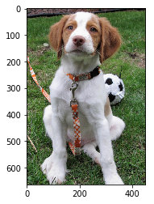

```
Dogs!
It looks like a Brittany
```

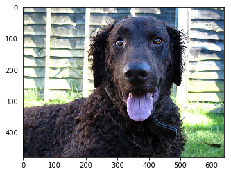

```
Dogs!
It looks like a Curly-coated retriever
```

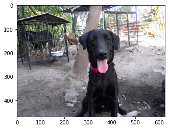

```
Dogs!
It looks like a Labrador retriever
```

[figure not shown]

```
Dogs!
It looks like a Labrador retriever
```

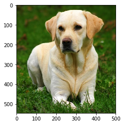

```
Dogs!
It looks like a Labrador retriever
```

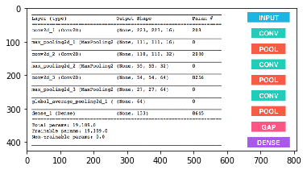

```
Error! Can't detect anything..
```

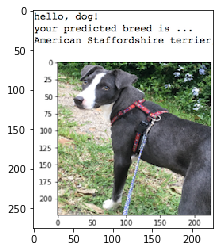

```
Dogs!
It looks like a Smooth fox terrier
```

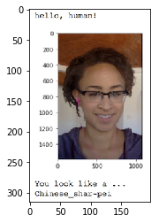

```
Human!
It looks like a Anatolian shepherd dog
```

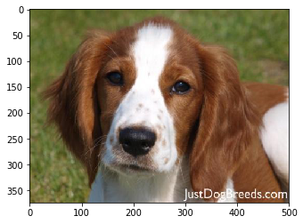

```
Dogs!
It looks like a Irish red and white setter
```

```python
from PIL import Image

for img_file in os.listdir('./images'):
    img_path = os.path.join('./images', img_file)
    run_app(img_path)
```

## 第 6 步：测试算法

在此部分测试新算法啦。算法认为看起来像哪种小狗？如果你有一只狗，算法能准确预测出小狗的品种吗？如果你有一只猫，算法会错误地认为这只猫是小狗吗？

### （实现）在样本图像上测试算法。

至少在计算机上用 6 张图像测试你的算法。你可以使用任何图像。至少测试两张人脸图像和两张小狗图像。

**问题 6：**结果比你预期的要好吗 :)?还是更糟糕 :(？请对你的算法提出至少三个值得改进的地方。

**答案：** 1.可以通过旋转 移动等方式进行图像增强来与优化训练数据； 2.对卡通风格的图像识别不准确，可以搜集更多图像数据集进行训练 3.进行超参数调优

```
## TODO: Execute your algorithm from Step 6 on
## at least 6 images on your computer.
## Feel free to use as many code cells as needed.

## suggested code, below
for file in np.hstack((human_files[:3], dog_files[:3])):
    run_app(file)
```

```python
my_human_files = np.array(glob("my_human_files/*"))
my_dog_files = np.array(glob("my_dog_files/*"))
```

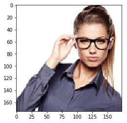

```
Human!
It looks like a Afghan hound
```

[figure not shown]

```
Human!
It looks like a Bull terrier
```

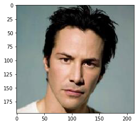

```
Human!
It looks like a Affenpinscher
```

[figure not shown]

```
Error! Can't detect anything..
```

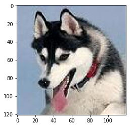

```
Error! Can't detect anything..
```

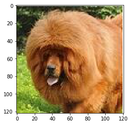

```
Dogs!
It looks like a Chow chow
```

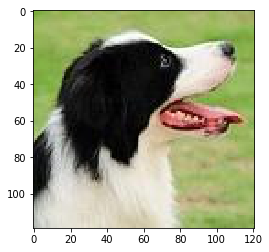

```
Dogs!
It looks like a Border collie
```

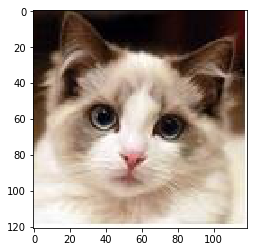

```
Error! Can't detect anything..
```

[figure not shown]

```
Error! Can't detect anything..
```

[figure not shown]

```
Error! Can't detect anything..
```

```python
## TODO: Execute your algorithm from Step 6 on

## at least 6 images on your computer.
## Feel free to use as many code cells as needed.

## suggested code, below
for file in np.hstack((my_human_files, my_dog_files)):
    run_app(file)
```